# Mapping dataset to the Humboldt Extension

## Get data

Get tsv files from Google Drive. Relationships between files are depicted in figure below.

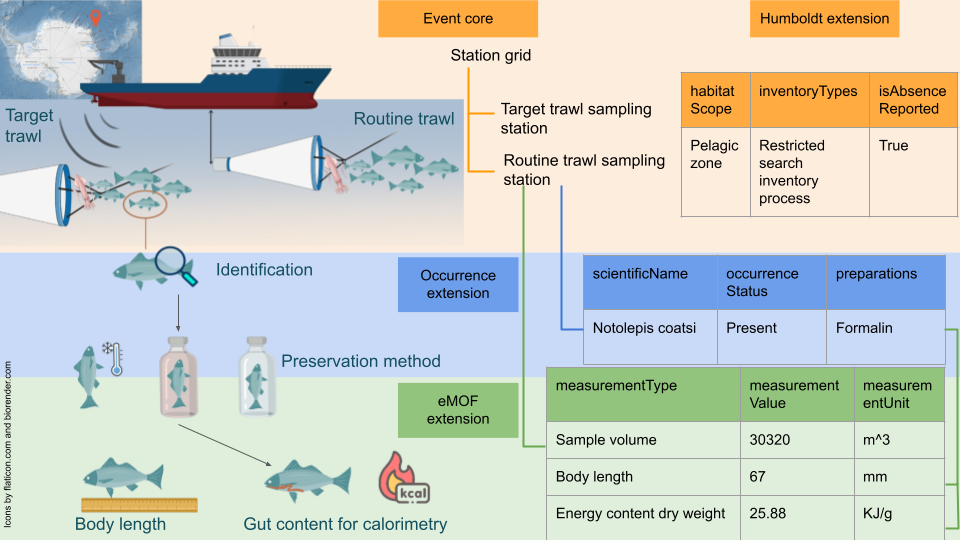

```r
library(tidyverse)

event <- read_tsv("https://docs.google.com/spreadsheets/d/e/2PACX-1vTzxqpYCe1tVdichPPMCVgP9fyY6duJrtgyO8zGwm7xMKL5WLb3l6MPq0Ke5TIlwU97ovdZ__ptkkMw/pub?gid=0&single=true&output=tsv", col_names = TRUE, show_col_types = FALSE)
occ <- read_tsv("https://docs.google.com/spreadsheets/d/e/2PACX-1vTzxqpYCe1tVdichPPMCVgP9fyY6duJrtgyO8zGwm7xMKL5WLb3l6MPq0Ke5TIlwU97ovdZ__ptkkMw/pub?gid=53360819&single=true&output=tsv", col_names = TRUE, show_col_types = FALSE)
humboldt <- read_tsv("https://docs.google.com/spreadsheets/d/e/2PACX-1vTzxqpYCe1tVdichPPMCVgP9fyY6duJrtgyO8zGwm7xMKL5WLb3l6MPq0Ke5TIlwU97ovdZ__ptkkMw/pub?gid=604710631&single=true&output=tsv", col_names = TRUE, show_col_types = FALSE)
target <- read_tsv("https://docs.google.com/spreadsheets/d/e/2PACX-1vTzxqpYCe1tVdichPPMCVgP9fyY6duJrtgyO8zGwm7xMKL5WLb3l6MPq0Ke5TIlwU97ovdZ__ptkkMw/pub?gid=872194191&single=true&output=tsv", col_names = TRUE, show_col_types = FALSE)
emof <- read_tsv("https://docs.google.com/spreadsheets/d/e/2PACX-1vTzxqpYCe1tVdichPPMCVgP9fyY6duJrtgyO8zGwm7xMKL5WLb3l6MPq0Ke5TIlwU97ovdZ__ptkkMw/pub?gid=2088877587&single=true&output=tsv", col_names = TRUE, show_col_types = FALSE)
```

## How to populate `eco:isTaxonomicScopeComplete`

The field `eco:isTaxonomicScopeComplete` is difficult to populate manually, so I am populating it with the script below.

If all `dwc:Organism` of an `dwc:Occurrence` from an `dwc:Event` are within `eco:targetTaxonomicScope`, set `eco:isTaxonomicScopeComplete` to `true`.

```r
# Perform left join on humboldt and occurrence tables
taxonomic_scope_joined_table <- humboldt %>%
  left_join(occ, by = "eventID", relationship = "many-to-many") %>%
  left_join(target, by = "scientificName", relationship = "many-to-many") %>%
  group_by(eventID, isTaxonomicScopeComplete) %>%
  # if all dwc:Organism of dwc:Occurrence of an dwc:Event are in targetTaxonomicScope
  mutate(isTaxonomicScopeComplete = all(!is.na(scientificName))) %>%
  select(eventID, isTaxonomicScopeComplete) %>%
  unique()

# Update the original humboldt table
humboldt$isTaxonomicScopeComplete <- taxonomic_scope_joined_table$isTaxonomicScopeComplete
humboldt %>% select(eventID, isTaxonomicScopeComplete) %>% head()
```

[output not shown]

## dwc:occurrenceStatus of presence-only dwc:Occurrence data

```r
library(tidyverse)

event <- read_tsv("https://docs.google.com/spreadsheets/d/e/2PACX-1vTzxqpYCe1tVdichPPMCVgP9fyY6duJrtgyO8zGwm7xMKL5WLb3l6MPq0Ke5TIlwU97ovdZ__ptkkMw/pub?gid=0&single=true&output=tsv", col_names = TRUE, show_col_types = FALSE)
occ <- read_tsv("https://docs.google.com/spreadsheets/d/e/2PACX-1vTzxqpYCe1tVdichPPMCVgP9fyY6duJrtgyO8zGwm7xMKL5WLb3l6MPq0Ke5TIlwU97ovdZ__ptkkMw/pub?gid=53360819&single=true&output=tsv", col_names = TRUE, show_col_types = FALSE)
humboldt <- read_tsv("https://docs.google.com/spreadsheets/d/e/2PACX-1vTzxqpYCe1tVdichPPMCVgP9fyY6duJrtgyO8zGwm7xMKL5WLb3l6MPq0Ke5TIlwU97ovdZ__ptkkMw/pub?gid=604710631&single=true&output=tsv", col_names = TRUE, show_col_types = FALSE)
target <- read_tsv("https://docs.google.com/spreadsheets/d/e/2PACX-1vTzxqpYCe1tVdichPPMCVgP9fyY6duJrtgyO8zGwm7xMKL5WLb3l6MPq0Ke5TIlwU97ovdZ__ptkkMw/pub?gid=872194191&single=true&output=tsv", col_names = TRUE, show_col_types = FALSE)
emof <- read_tsv("https://docs.google.com/spreadsheets/d/e/2PACX-1vTzxqpYCe1tVdichPPMCVgP9fyY6duJrtgyO8zGwm7xMKL5WLb3l6MPq0Ke5TIlwU97ovdZ__ptkkMw/pub?gid=2088877587&single=true&output=tsv", col_names = TRUE, show_col_types = FALSE)
```

### Inferring non-detection from presence-only data using Humboldt Extension

```r
# Perform left join on humboldt and occurrence tables
taxonomic_scope_joined_table <- humboldt %>%
  left_join(occ, by = "eventID", relationship = "many-to-many") %>%
  left_join(target, by = "scientificName", relationship = "many-to-many") %>%
  group_by(eventID, isTaxonomicScopeComplete) %>%
  # if all dwc:Organism of dwc:Occurrence of an dwc:Event are in targetTaxonomicScope
  mutate(isTaxonomicScopeComplete = all(!is.na(scientificName))) %>%
  select(eventID, isTaxonomicScopeComplete) %>%
  unique()

# Update the original humboldt table
humboldt$isTaxonomicScopeComplete <- taxonomic_scope_joined_table$isTaxonomicScopeComplete
humboldt %>% select(eventID, isTaxonomicScopeComplete) %>% head()
```

| eventID | isTaxonomicScopeComplete |
| --- | --- |
| BROKE_WEST | FALSE |
| BROKE_WEST_RMT_001 | TRUE |
| BROKE_WEST_RMT_002 | FALSE |
| BROKE_WEST_RMT_003 | FALSE |
| BROKE_WEST_RMT_022 | TRUE |
| BROKE_WEST_RMT_004 | TRUE |

### How to populate eco:isLifeStageScopeComplete

I have difficulty writing a script for `eco:isLifeStageScopeComplete`, so I did it manually.

| conditions | eco:isLifeStageScopeComplete |
| --- | --- |
| if dwc:lifeStage of an dwc:Organism from eco:targetTaxonomicScope is not recorded, but eco:targetLifeStageScope == “all” | true |

#### What not to do

If you know what are the life stages applicable for your target taxa, please list them **all out** instead of using `all`. This allows user to make inference about the non-detection of the taxon at its specific life stage.

## Remarks

- difference between `eco:taxonCompletenessReported` and `eco:isTaxonomicScopeComplete` ?
- completeness (`eco:isLifeStageScopeComplete`) per event instead of per target taxa is limiting the information that can be inferred.
- how to fill in `eco:excludedLifeStageScope` when there is `none` (`eco:targetLifeStageScope` == all life stages). Because of the way the data is ordered alongside with `eco:targetTaxonomicScope`. Can’t make inference if there is only `eco:targetLifeStageScope` without explicit `eco:excludedLifeStageScope`
- lack of identifiers for `dwc:scientificName` in `eco:targetTaxonomicScope` may be problematic for homonyms.
- the mapping was done to explore dwciri of terms could be used in IPT: https://github.com/gbif/ipt/issues/1947